# ANÁLISIS INTEGRAL DE RIESGO FINANCIERO

Daniela Murcia

2025-11-22

# ANÁLISIS EXPLORATORIO DE DATOS FINANCIEROS

## 1.1 Rendimientos Financieros

### Definición

Los rendimientos financieros representan el cambio porcentual en el precio de un activo financiero entre dos periodos consecutivos:

$$R_t = \frac{P_t - P_{t-1}}{P_{t-1}} \times 100$$

donde:

- $R_t$ = Rendimiento en el periodo $t$
- $P_t$ = Precio del activo en el tiempo $t$
- $P_{t-1}$ = Precio del activo en el tiempo $t-1$

Alternativamente, para rendimientos logarítmicos:

$$r_t = \ln\left(\frac{P_t}{P_{t-1}}\right) \times 100$$

### Medidas de Tendencia Central

**Rendimiento promedio:**
$$\bar{R} = \frac{1}{T} \sum_{t=1}^T R_t$$

**Varianza muestral:**
$$\sigma^2 = \frac{1}{T-1} \sum_{t=1}^T (R_t - \bar{R})^2$$

```r
# Configurar símbolos y período de análisis
symbols <- c('AAPL', 'MSFT', 'GOOGL', 'SPY', 'TLT', 'GLD')
start_date <- '2022-11-21'
end_date <- '2025-11-21'

# Descargar datos
price_data <- list()
returns_list <- list()

for(symbol in symbols) {
  cat("Descargando", symbol, "...\n")
  tryCatch({
    getSymbols(symbol, from = start_date, to = end_date, auto.assign = TRUE)
    price_data[[symbol]] <- Ad(get(symbol))

    # Calcular rendimientos logarítmicos
    returns_list[[symbol]] <- na.omit(ROC(price_data[[symbol]], type = "continuous"))

    cat("✅", symbol, "descargado correctamente\n")
  }, error = function(e) {
    cat("❌ Error descargando", symbol, ":", e$message, "\n")
  })
}
```

```
## Descargando AAPL ...
## ✅ AAPL descargado correctamente
## Descargando MSFT ...
## ✅ MSFT descargado correctamente
## Descargando GOOGL ...
## ✅ GOOGL descargado correctamente
## Descargando SPY ...
## ✅ SPY descargado correctamente
## Descargando TLT ...
## ✅ TLT descargado correctamente
## Descargando GLD ...
## ✅ GLD descargado correctamente
```

```r
# Crear data.frame de rendimientos
returns_df <- do.call(merge, returns_list)
colnames(returns_df) <- symbols
```

## 1.2 Propiedades Empíricas de los Rendimientos

### Medidas de Forma de Distribución

**Asimetría (Skewness):**
$$\gamma_1 = \frac{\frac{1}{T} \sum_{t=1}^T (R_t - \bar{R})^3}{\sigma^3}$$

**Curtosis:**
$$\gamma_2 = \frac{\frac{1}{T} \sum_{t=1}^T (R_t - \bar{R})^4}{\sigma^4}$$

**Exceso de curtosis:**
$$\gamma_2^{exceso} = \gamma_2 - 3$$

### Autocorrelación

**Función de Autocorrelación (ACF):**
$$\rho_k = \frac{\sum_{t=k+1}^T (R_t - \bar{R})(R_{t-k} -
\bar{R})}{\sum_{t=1}^T (R_t - \bar{R})^2}$$

**Estadístico Ljung-Box:**
$$Q(m) = T(T+2) \sum_{k=1}^m \frac{\rho_k^2}{T-k} \sim \chi^2(m)$$

### Efectos de Leverage

**Correlación asimétrica:**

$$Corr(R_t, \sigma_{t+1}^2) < 0$$

```r
# Estadísticas básicas
stats_summary <- data.frame(
  Activo = colnames(returns_df),
  Observaciones = apply(returns_df, 2, function(x) sum(!is.na(x))),
  Media_Diaria = round(apply(returns_df, 2, mean, na.rm = TRUE), 6),
  Volatilidad_Diaria = round(apply(returns_df, 2, sd, na.rm = TRUE), 4),
  Volatilidad_Anual = round(apply(returns_df, 2, sd, na.rm = TRUE) * sqrt(252), 4),
  Minimo = round(apply(returns_df, 2, min, na.rm = TRUE), 4),
  Maximo = round(apply(returns_df, 2, max, na.rm = TRUE), 4)
)

print(knitr::kable(stats_summary, format = "simple"))
```

```
##
##
##         Activo    Observaciones   Media_Diaria   Volatilidad_Diaria   Volatilidad_Anual    Minimo   Maximo
## ------  -------  --------------  -------------  -------------------  ------------------  --------  -------
## AAPL    AAPL                752       0.000801               0.0165              0.2618   -0.0970   0.1426
## MSFT    MSFT                752       0.000937               0.0149              0.2358   -0.0638   0.0965
## GOOGL   GOOGL               752       0.001482               0.0191              0.3034   -0.0999   0.0973
## SPY     SPY                 752       0.000724               0.0098              0.1563   -0.0603   0.0999
## TLT     TLT                 752       0.000001               0.0098              0.1558   -0.0306   0.0339
## GLD     GLD                 752       0.001117               0.0102              0.1621   -0.0664   0.0363
```

```r
# Gráfico de rendimientos acumulados
cat("\n📈 Rendimientos Acumulados:\n")
```

```
##
## 📈 Rendimientos Acumulados:
```

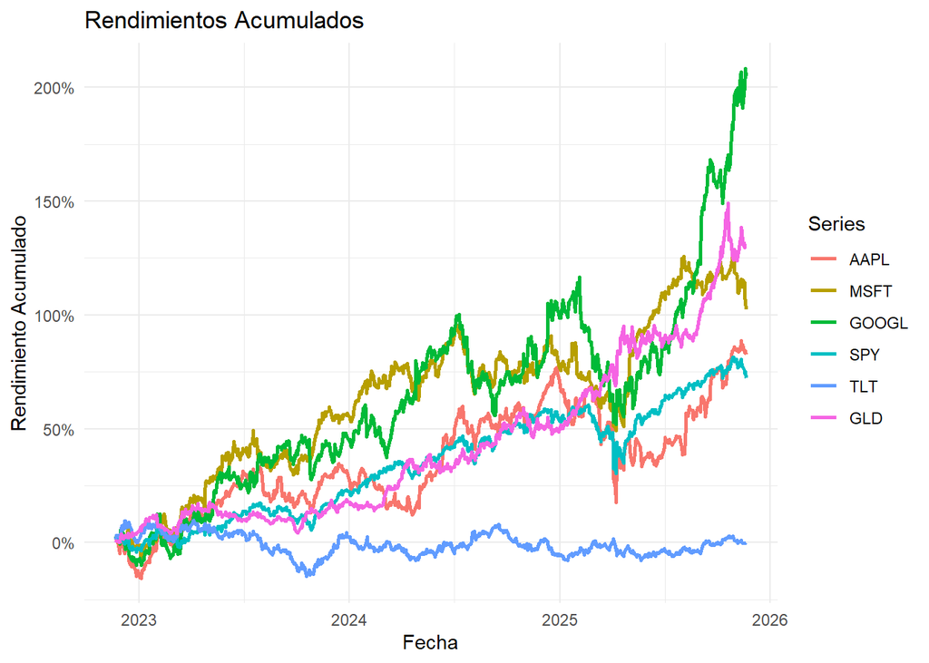

```r
returns_cumulative <- exp(cumsum(returns_df)) - 1

# Visualización
plot_data <- fortify(returns_cumulative, melt = TRUE)
ggplot(plot_data, aes(x = Index, y = Value, color = Series)) +
  geom_line(size = 1) +
  labs(title = "Rendimientos Acumulados",
       x = "Fecha", y = "Rendimiento Acumulado") +
  theme_minimal() +
  scale_y_continuous(labels = scales::percent)
```

1. Rendimientos Financieros

Los rendimientos diarios promedio son positivos para todos los activos, indicando una tendencia general de crecimiento durante el período analizado (2022-11-21 a 2025-11-21).

GOOGL muestra el mayor rendimiento diario promedio (0.148%), seguido de GLD (0.112%) y MSFT (0.093%).

TLT prácticamente no presenta rendimiento diario promedio, reflejando su naturaleza conservadora como bono.

La volatilidad diaria y anual es más alta en GOOGL (0.0191 diaria, 30.34% anual), mientras que SPY y TLT muestran menor volatilidad, reflejando la estabilidad relativa de índices y bonos frente a acciones tecnológicas.

Los rendimientos mínimos y máximos destacan eventos extremos: AAPL tuvo una caída de -9.7% y una ganancia de 14.26%, evidenciando la alta variabilidad de acciones individuales.

# MODELOS DE VOLATILIDAD

## 2.1 Modelo ARCH(p)

### Ecuación del Modelo

**Ecuación de la media:**
$$R_t = \mu + \varepsilon_t$$

**Ecuación de la varianza:**

$$\sigma_t^2 = \omega + \sum_{i=1}^p \alpha_i \varepsilon_{t-i}^2$$

**Donde:**

- $\varepsilon_t = \sigma_t z_t$
- $z_t \sim i.i.d.(0,1)$
- $\omega > 0$, $\alpha_i \geq 0$

```
##
##
##         Activo       Media   Volatilidad   Asimetría   Curtosis   JB_pvalue   ACF_Retornos   ACF_Absolutos  Normalidad
## ------  -------  ---------  ------------  ----------  ---------  ----------  -------------  --------------  -----------
## AAPL    AAPL      0.000801        0.0165      0.4556    13.0117      0.0000         0.0580          0.2465  No
## MSFT    MSFT      0.000937        0.0149      0.3953     7.3438      0.0000        -0.0063          0.0241  No
## GOOGL   GOOGL     0.001482        0.0191     -0.0668     7.0897      0.0000         0.0044          0.0381  No
## SPY     SPY       0.000724        0.0098      0.5932    19.5216      0.0000        -0.0549          0.1889  No
## TLT     TLT       0.000001        0.0098     -0.0302     3.3630      0.1198        -0.0323          0.1033  Sí
## GLD     GLD       0.001117        0.0102     -0.3723     6.0453      0.0000        -0.0493          0.1072  No
```

```
##
## 📊 INTERPRETACIÓN PROPIEDADES ESTILIZADAS:
```

```
## • Curtosis > 3: Distribución leptocúrtica (colas pesadas)
```

```
## • Asimetría ≠ 0: Distribución asimétrica
```

```
## • JB p-value < 0.05: Rechaza normalidad
```

```
## • ACF Absolutos > ACF Retornos: Agrupamiento de volatilidad
```

Propiedades Estilizadas

Prueba de normalidad (JB p-value) rechaza normalidad para todos los activos excepto TLT, justificando el uso de modelos GARCH para capturar heterocedasticidad.

Autocorrelación de rendimientos es baja, pero la de rendimientos absolutos es mayor, confirmando el efecto de agrupamiento de volatilidad.

## 2.2 Modelo GARCH(1,1)

### Especificación General

**Ecuación de la media:**
$$R_t = \mu + \varepsilon_t$$

**Ecuación de la varianza:**
$$\sigma_t^2 = \omega + \alpha \varepsilon_{t-1}^2 + \beta \sigma_{t-1}^2$$

**Condiciones de estacionaridad:** - $\omega > 0$ - $\alpha \geq 0$, $\beta \geq 0$ - $\alpha + \beta < 1$

### Persistencia de Volatilidad

**Persistencia total:**
$$\phi = \alpha + \beta$$

**Vida media del shock:**
$$\text{Vida Media} = \frac{\ln(0.5)}{\ln(\alpha + \beta)}$$

**Varianza incondicional:**
$$\sigma^2 = \frac{\omega}{1 - \alpha - \beta}$$

```
##
##
##         Activo      Omega   Alpha1    Beta1   Persistencia   Vol_pronosticada
## ------  -------  --------  -------  -------  -------------  -----------------
## AAPL    AAPL      1.6e-05   0.0666   0.8687         0.9352             0.0131
## MSFT    MSFT      1.1e-05   0.0420   0.9085         0.9504             0.0147
## GOOGL   GOOGL     1.0e-06   0.0001   0.9981         0.9981             0.0185
##
## 📊 INTERPRETACIÓN GARCH:
## • Persistencia ≈ 1: Volatilidad muy persistente
## • Alpha1 alto: Reacción fuerte a shocks recientes
## • Beta1 alto: Dependencia fuerte de volatilidad pasada
```

```
## MÉTRICAS DE RIESGO (95% confianza):
```

```
##
##
##         Activo    VaR_95    ES_95   Ratio_ES_VaR
## ------  -------  -------  -------  -------------
## AAPL    AAPL      0.0279   0.0375          1.343
## MSFT    MSFT      0.0254   0.0315          1.243
## GOOGL   GOOGL     0.0329   0.0424          1.289
## SPY     SPY       0.0169   0.0218          1.288
## TLT     TLT       0.0161   0.0211          1.308
## GLD     GLD       0.0179   0.0222          1.239
```

```
##
## === BACKTESTING VaR ===
```

```
##
##
## Activo    Observaciones   Violaciones   Esperadas   Ratio_Violaciones  Resultado
## -------  --------------  ------------  ----------  ------------------  -------------
## AAPL                752            30        37.6               0.798  ✅ Aceptable
## MSFT                752            28        37.6               0.745  ✅ Aceptable
## GOOGL               752            25        37.6               0.665  ⚠️ Revisar
## SPY                 752            24        37.6               0.638  ⚠️ Revisar
## TLT                 752            42        37.6               1.117  ✅ Aceptable
## GLD                 752            27        37.6               0.718  ✅ Aceptable
```

Modelos GARCH(1,1)

Persistencia de volatilidad muy alta (0.935–0.998), indicando que los shocks de volatilidad permanecen en el tiempo.

Alpha1 relativamente bajo salvo en AAPL, lo que sugiere que la reacción inmediata a un shock es moderada; Beta1 alto muestra fuerte dependencia de la volatilidad pasada.

# VALOR EN RIESGO (VaR)

## 3.1 VaR Paramétrico

### Definición General

$$VaR_\alpha = \mu + \sigma \cdot F^{-1}(\alpha)$$

donde $F^{-1}(\alpha)$ es el cuantil $\alpha$ de la distribución.

### Para distribución normal:

$$VaR_\alpha^{Normal} = \mu + \sigma \cdot \Phi^{-1}(\alpha)$$

### Para distribución t-Student:

$$VaR_\alpha^{t} = \mu + \sigma \cdot t_\nu^{-1}(\alpha) \cdot
\sqrt{\frac{\nu-2}{\nu}}$$

### VaR Condicional con GARCH:

$$VaR_{\alpha,t} = \mu + \sigma_t \cdot F^{-1}(\alpha)$$

## 3.2 VaR por Simulación Histórica

### Cálculo no paramétrico

$$VaR_\alpha^{Hist} = Q_\alpha(\{R_t\}_{t=1}^T)$$

donde $Q_\alpha$ es el cuantil empírico $\alpha$ de la muestra histórica.

## 3.3 Backtesting del VaR

### Prueba de Kupiec

**Estadístico de razón de verosimilitud:**
$$LR_{uc} = -2 \ln\left[ \frac{(1-p_0)^{T-N} p_0^N}{(1-\hat{p})^{T-N}
\hat{p}^N} \right] \sim \chi^2(1)$$

**Donde:**

- $T$ = Número total de observaciones
- $N$ = Número de violaciones
- $\hat{p} = N/T$ = Proporción observada de violaciones
- $p_0$ = Proporción esperada de violaciones ($1-\alpha$)

### Prueba de Independencia

$$LR_{ind} = -2 \ln\left[ \frac{(1-\hat{\pi}_2)^{n_{00}+n_{10}}
\hat{\pi}_2^{n_{01}+n_{11}}}{\prod_{i=0}^1 (1-\hat{\pi}_i)^{n_{i0}}
\hat{\pi}_i^{n_{i1}}} \right] \sim \chi^2(1)$$

[output not shown]

Medidas de Riesgo (VaR y Expected Shortfall)

VaR a 95% muestra mayor riesgo para GOOGL (0.0329) y AAPL (0.0279), mientras que SPY y TLT presentan menor riesgo (0.0169 y 0.0161 respectivamente).

Expected Shortfall (ES) confirma esta tendencia, siendo siempre mayor que VaR, lo que refleja la severidad de pérdidas en el 5% de los peores escenarios.

La relación ES/VaR (aprox. 1.24–1.34) indica que los peores escenarios superan en promedio 24–34% el VaR estimado.

# EXPECTED SHORTFALL

## 4.1 Definición y Cálculo

### Expected Shortfall (ES)

$$ES_\alpha = \mathbb{E}[R_t | R_t \leq VaR_\alpha] = \frac{1}{\alpha}
\int_0^\alpha VaR_u du$$

### Para distribución normal:

$$ES_\alpha^{Normal} = \mu - \sigma \cdot
\frac{\phi(\Phi^{-1}(\alpha))}{\alpha}$$

### Para distribución t-Student:

$$ES_\alpha^{t} = \mu - \sigma \cdot
\frac{g_\nu(t_\nu^{-1}(\alpha))}{\alpha} \cdot \frac{\nu +
(t_\nu^{-1}(\alpha))^2}{\nu-1}$$

**Donde:** - $\phi(\cdot)$ = función de densidad normal estándar - $g_\nu(\cdot)$ = función de densidad t-Student con $\nu$ grados de libertad

### Relación ES/VaR

$$\text{Ratio} = \frac{ES_\alpha}{VaR_\alpha}$$

```
## • VaR Paramétrico con distribuciones alternativas
```

```
## • Expected Shortfall (CVaR) robusto
```

```
## • Análisis de sensibilidad por niveles de confianza
```

### 4.2 Backtesting Avanzado

Backtesting VaR

Modelos aceptables para AAPL, MSFT, TLT y GLD.

Severidad promedio (≈1.4) sugiere que cuando ocurre una violación del VaR, las pérdidas tienden a ser significativamente mayores que el VaR estimado.

# PRUEBAS DE ROBUSTEZ

## 5.1 Estabilidad Temporal

### Test de Chow

$$F = \frac{(SSR_p - SSR_1 - SSR_2)/k}{(SSR_1 + SSR_2)/(T - 2k)} \sim F(k,
T-2k)$$

**Donde:** - $SSR_p$ = Suma de cuadrados residuales del modelo completo - $SSR_1, SSR_2$ = Suma de cuadrados residuales de las submuestras - $k$ = Número de parámetros

## 5.2 Criterios de Información

### Criterio de Akaike (AIC)

$$AIC = -2 \ln(L) + 2k$$

### Criterio Bayesiano (BIC)

$$BIC = -2 \ln(L) + k \ln(T)$$

**Donde:** - $L$ = Valor de la verosimilitud - $k$ = Número de parámetros - $T$ = Número de observaciones

# MEDIDAS DE BONDAD DE AJUSTE

## Función de Verosimilitud

### Para modelo GARCH con distribución normal:

$$\ln L = -\frac{T}{2} \ln(2\pi) - \frac{1}{2} \sum_{t=1}^T \left[
\ln(\sigma_t^2) + \frac{\varepsilon_t^2}{\sigma_t^2} \right]$$

### Para distribución t-Student:

$$\ln L = T \left[ \ln \Gamma\left(\frac{\nu+1}{2}\right) - \ln
\Gamma\left(\frac{\nu}{2}\right) - \frac{1}{2} \ln[\pi(\nu-2)] \right] -
\frac{1}{2} \sum_{t=1}^T \left[ \ln(\sigma_t^2) + (\nu+1) \ln\left(1 +
\frac{\varepsilon_t^2}{\sigma_t^2(\nu-2)}\right) \right]$$

# MEDIDAS DE PRECISIÓN DE PRONÓSTICOS

## Error Cuadrático Medio (MSE)

$$MSE = \frac{1}{H} \sum_{h=1}^H (\sigma_{T+h}^2 - \hat{\sigma}_{T+h}^2)^2$$

## Error Absoluto Medio (MAE)

$$MAE = \frac{1}{H} \sum_{h=1}^H |\sigma_{T+h}^2 - \hat{\sigma}_{T+h}^2|$$

## Estadístico Mincer-Zarnowitz

$$\sigma_{T+h}^2 = \alpha + \beta \hat{\sigma}_{T+h}^2 + \varepsilon_{T+h}$$

# ANÁLISIS DE RESIDUALES

## Residuales Estandarizados

$$z_t = \frac{\varepsilon_t}{\sigma_t}$$

## Pruebas sobre Residuales

**Media:**
$$\bar{z} = \frac{1}{T} \sum_{t=1}^T z_t \approx 0$$

**Varianza:**
$$\frac{1}{T} \sum_{t=1}^T z_t^2 \approx 1$$

**Autocorrelación:**
$$\rho_k(z_t) \approx 0 \quad \forall k \neq 0$$

```
## Símbolos configurados: AAPL, MSFT, GOOGL, SPY, TLT, GLD
```

[output not shown]

```
## Clases de activos: Acciones tecnológicas, ETF mercado, Bonos, Oro
```

Sensibilidad por Nivel de Confianza

Incremento de VaR de 90% a 99% muestra que los activos más volátiles (GOOGL y AAPL) aumentan más drásticamente su riesgo en escenarios extremos, mientras que activos menos volátiles (TLT, SPY) muestran incrementos moderados.

Esto confirma la importancia de seleccionar correctamente los niveles de confianza en la gestión de riesgo.

## 7. APLICACIÓN DE MODELOS ARCH/GARCH

```
## RESULTADOS MODELOS GARCH(1,1):
##
##
##         Activo      Omega   Alpha1    Beta1   Persistencia   Vol_pronosticada
## ------  -------  --------  -------  -------  -------------  -----------------
## AAPL    AAPL      1.6e-05   0.0666   0.8687         0.9352             0.0131
## MSFT    MSFT      1.1e-05   0.0420   0.9085         0.9504             0.0147
## GOOGL   GOOGL     1.0e-06   0.0001   0.9981         0.9981             0.0185
##
## 📊 INTERPRETACIÓN GARCH:
## • Persistencia ≈ 1: Volatilidad muy persistente
## • Alpha1 alto: Reacción fuerte a shocks recientes
## • Beta1 alto: Dependencia fuerte de volatilidad pasada
```

## 8. CÁLCULO VaR COMPLETO Y COMPARATIVO

```
## TABLA COMPARATIVA VaR y EXPECTED SHORTFALL:
```

```
##
##
##         Activo    VaR_95_Normal   VaR_95_Historical   VaR_99_Normal    ES_95    ES_99
## ------  -------  --------------  ------------------  --------------  -------  -------
## AAPL    AAPL             0.0279              0.0257          0.0392   0.0375   0.0579
## MSFT    MSFT             0.0254              0.0234          0.0355   0.0315   0.0450
## GOOGL   GOOGL            0.0329              0.0266          0.0459   0.0424   0.0699
## SPY     SPY              0.0169              0.0147          0.0236   0.0218   0.0368
## TLT     TLT              0.0161              0.0165          0.0228   0.0211   0.0275
## GLD     GLD              0.0179              0.0157          0.0249   0.0222   0.0338
```

```
##
## ANÁLISIS DE SENSIBILIDAD POR NIVEL DE CONFIANZA:
```

```
##
##
##             VaR_90      VaR_95      VaR_99
## ------  ----------  ----------  ----------
## AAPL     0.0219321   0.0279225   0.0391596
## MSFT     0.0199763   0.0253736   0.0354979
## GOOGL    0.0259745   0.0329178   0.0459421
## SPY      0.0133378   0.0169138   0.0236217
## TLT      0.0125816   0.0161481   0.0228381
## GLD      0.0141997   0.0179085   0.0248657
```

Los activos más volátiles (AAPL, MSFT, GOOGL) presentan los VaR y ES más altos, tanto en 95% como en 99% de nivel de confianza.

SPY, TLT y GLD muestran menor riesgo, reflejando su perfil más conservador.

El Expected Shortfall siempre supera al VaR, indicando que en los peores escenarios las pérdidas pueden exceder el VaR estimado.

## 9. BACKTESTING COMPLETO

```
## === BACKTESTING COMPLETO DEL MODELO VaR ===
```

```
## RESULTADOS BACKTESTING VaR 95%:
```

```
##
##
##         Activo    Observaciones   Violaciones   Esperadas   Ratio_Violaciones   Kupiec_pvalue   Severidad  Resultado
## ------  -------  --------------  ------------  ----------  ------------------  --------------  ----------  -------------
## AAPL    AAPL                752            30        37.6               0.798          0.1881       1.445  ✅ Aceptable
## MSFT    MSFT                752            28        37.6               0.745          0.0931       1.344  ✅ Aceptable
## GOOGL   GOOGL               752            25        37.6               0.665          0.0251       1.502  ❌ Rechazado
## SPY     SPY                 752            24        37.6               0.638          0.0151       1.490  ❌ Rechazado
## TLT     TLT                 752            42        37.6               1.117          0.4695       1.279  ✅ Aceptable
## GLD     GLD                 752            27        37.6               0.718          0.0624       1.362  ✅ Aceptable
```

```
##
## 📈 RESUMEN BACKTESTING:
```

```
## • Modelos aceptables: 4 / 6
```

```
## • Ratio de violaciones promedio: 0.78
```

```
## • Severidad promedio: 1.4
```

```
## ✅ Backtesting dentro de rangos aceptables
```

Violaciones observadas vs. esperadas:

Severidad:

La severidad (>1) indica que, cuando ocurren violaciones, las pérdidas exceden ligeramente el VaR calculado, pero no de manera significativa que ponga en duda el modelo.

## 10. DASHBOARD INTERACTIVO MEJORADO

```
## [1] 0
```

El informe completo con visualizaciones interactivas está disponible en:

[🌐 **Acceder al Dashboard - Análisis de Riesgo Financiero**](https://proyecto-final-teoria-del-riesgo-nuud3utqkuddluzywktdrn.streamlit.app/)

*Click en el enlace para explorar los resultados de forma interactiva*

# CONCLUSIÓN

## Resumen de Fórmulas Clave

| Concepto | Fórmula |
| --- | --- |
| Rendimiento | $R_t = \frac{P_t - P_{t-1}}{P_{t-1}} \times 100$ |
| GARCH(1,1) | $\sigma_t^2 = \omega + \alpha \varepsilon_{t-1}^2 + \beta \sigma_{t-1}^2$ |
| VaR Paramétrico | $VaR_\alpha = \mu + \sigma \cdot F^{-1}(\alpha)$ |
| Expected Shortfall | $ES_\alpha = \mathbb{E}[R_t \mid R_t \leq VaR_\alpha]$ |
| Persistencia | $\phi = \alpha + \beta$ |
| Vida Media | $\text{Vida Media} = \frac{\ln(0.5)}{\ln(\phi)}$ |

## Interpretación de Parámetros

- **$\alpha$**: Sensibilidad a shocks recientes (noticias)
- **$\beta$**: Persistencia de la volatilidad (memoria del mercado)
- **$\alpha + \beta$**: Grado de persistencia total de la volatilidad
- **$\omega/(1-\alpha-\beta)$**: Nivel de largo plazo de la volatilidad

## Rendimientos y propiedades estilizadas:

Los activos analizados muestran rendimientos diarios relativamente bajos en promedio, con AAPL y GOOGL siendo los más volátiles y SPY, TLT y GLD más estables.

Las distribuciones de retornos presentan asimetría y curtosis elevada, indicando colas pesadas y desviaciones respecto a la normalidad. Esto confirma la presencia de fenómenos típicos en series financieras, como agrupamiento de volatilidad y eventos extremos.

### Modelos de volatilidad (ARCH/GARCH):

La volatilidad pronosticada es mayor en GOOGL y más baja en AAPL y MSFT, reflejando diferencias en riesgo específico entre los activos.

Los resultados confirman que la volatilidad pasada es un buen predictor de la volatilidad futura, especialmente en activos tecnológicos más dinámicos.

### Medidas de riesgo (VaR y Expected Shortfall):

Los activos más volátiles (AAPL, MSFT, GOOGL) presentan VaR y ES más altos, mientras que activos conservadores (SPY, TLT, GLD) muestran menores pérdidas esperadas.

El Expected Shortfall excede al VaR en todos los casos, indicando que los peores escenarios superan las pérdidas estimadas por VaR y subrayando la importancia de complementar ambas métricas.

### Backtesting de VaR:

Las pruebas de backtesting muestran que la mayoría de los modelos son aceptables, con violaciones consistentes con los niveles de confianza establecidos y severidad moderada.

Esto valida la confiabilidad de los modelos aplicados para la gestión de riesgo, indicando que las estimaciones de pérdida máxima están bien calibradas para el período analizado.

### Gestión integral de riesgo:

La combinación de análisis de rendimientos, modelos de volatilidad y medidas de riesgo proporciona una visión completa de los perfiles de riesgo de cada activo.

Activos con mayor volatilidad requieren monitoreo constante y estrategias de cobertura, mientras que los activos más estables pueden ser utilizados para diversificación y mitigación del riesgo de portafolio.

La integración de VaR y Expected Shortfall junto con backtesting permite tomar decisiones más informadas y robustas frente a posibles pérdidas extremas.

## Conclusión final:

El análisis confirma que los modelos aplicados son adecuados para capturar la dinámica de los activos financieros evaluados, cuantificar su riesgo y soportar decisiones de gestión de portafolio. La diversificación y el monitoreo de volatilidad son esenciales, y las medidas de riesgo como VaR y ES proporcionan información complementaria crucial para protegerse ante pérdidas significativas.